# Graphical Analysis

Author

Josie Athens

Published

July 10, 2024

```r
library(tidyverse)
library(easystats)
library(ggfortify)
library(pubh)
library(sjlabelled)

library(GGally)

jama = ggsci::scale_color_jama()
import::from(latex2exp, TeX)
import::from(epiDisplay, ci)
import::from(mosaic, xpnorm, xqnorm)
theme_set(see::theme_lucid(base_size = 10))
options('huxtable.knit_print_df' = FALSE)
options('huxtable.autoformat_number_format' = list(numeric = "%5.2f"))

library("repr")
options(repr.plot.width=6, repr.plot.height=4)
```

# 1 Overview

It would be impossible to cover all possible `R` graphs in this laboratory, let alone all the useful options for each type of graph, so we will focus on identifying the main types of graphs and look at some commonly used options. Once you have mastered the basic principles covered in this laboratory, you should be well prepared to construct basic graphs.

This lab has several optional sections, you are welcome to do to those sections or simply use them as a reference for making plots.

Once you have completed this lab, you should feel comfortable:

- Constructing histograms and density plots.
- Constructing scatter plots (both bivariate and matrix) and line charts.
- Constructing box plots.
- Constructing QQ-plots.
- Constructing strip charts.
- Constructing bar charts.
- Adding titles and labels to these graphs.
- Customising these graphs by setting appropriate options.
- Exporting plots for publications or other purposes.

## 1.1 Summary of New Commands

| **Command** | **Library** | **Function** |
| --- | --- | --- |
| **autoplot** | *ggplot2* | Plots objects from different classes |
| **axis_labs** | *pubh* | Uses labels from labelled data for axis legends |
| **bar_error** | *pubh* | Constructs bar charts with error bars |
| **box_plot** | *pubh* | Constructs box-plots |
| **correlation** | *correlation* | Estimates correlation coefficients |
| **dev.off** | *grDevices* | Closes the current graphing device |
| **get_label** | *sjlabelled* | Retrieves variable label |
| **gf_counts** | *ggformula* | Constructs bar plots (using counts) |
| **gf_dens** | *ggformula* | Constructs density plots (contour) |
| **gf_density** | *ggformula* | Constructs density plots (filled) |
| **gf_dhistogram** | *ggformula* | Constructs histograms in terms of density |
| **gf_histogram** | *ggformula* | Constructs histograms in terms of frequency |
| **gf_jitter** | *ggformula* | Constructs strip charts |
| **gf_line** | *ggformula* | Constructs line charts |
| **gf_labs** | *ggformula* | Edits plot’s labels (axis, mains, facets) |
| **gf_lm** | *ggformula* | Fits a simple linear model to a scatter plot |
| **gf_point** | *ggformula* | Constructs scatter plots |
| **gf_refine** | *ggformula* | Used to change scales and theme in a plot |
| **gf_smooth** | *ggformula* | Adds a loess fit (trend) to a scatter plot |
| **gf_star** | *pubh* | Adds a significant line for annotating plots |
| **gf_summary** | *ggformula* | Aggregates data by statistics to add to a plot |
| **gf_theme** | *ggformula* | Changes aspects of the theme |
| **gf_violin** | *ggformula* | Constructs violin plots |
| **ggpairs** | *GGally* | Constructs scatter plot matrices |
| **his_norm** | *pubh* | Constructs histograms with normal curve |
| **na.omit** | *stats* | Removes observations with missing values from a dataset |
| **pdf** | *grDevices* | Exports figures as PDF |
| **pivot_longer** | *dplyr* | Transforms data from wide to long format |
| **plot_scatter** | *sjPlot* | Constructs scatter plots |
| **postscript** | *grDevices* | Exports figures as EPS files |
| **qq_plot** | *pubh* | Constructs QQ-plots |
| **remove_all_labels** | *sjlabelled* | Removes labels from a dataset |
| **sjplot** | *sjPlot* | Constructs plots using pipe-workflow |
| **stat_compare_means** | *ggpubr* | Adds a significant line for annotating plots |
| **strip_error** | *pubh* | Constructs strip plots with error bars |

# 2 Introduction

Chapter 4 of [@iswr] shows how to do basic descriptive statistics, as well as the classic plots in `R`. There are more graphic packages that allow better graphics, one of them is `ggplot2` whose syntax is relatively complex. We will be using the package `ggformula` which simplifies syntax for constructing plots with `ggplot2` using formulas as part of its syntax. The package is loaded in the system when you load the `pubh` package.

There are different reasons to make a plot. For manuscripts and reports, plots in black and white (B&W) are sometimes preferred (as figures in colour have an extra cost). However, if you want to show your plots in a presentation or a poster, a colour would be more appropriate.

**For manuscripts**

1. Include figure legends (captions).
2. The *main* title is not included in the plot but as part of the description in the legend.
3. Use B&W plots, you can use any variation of grey.
4. Export the plot as a `.eps` or `.pdf` file (see last section).

**For reports, including assignments**

1. Include figure legends (captions).
2. The *main* title is not included in the plot but as part of the description in the legend.
3. You can play with colours, but be smart, e.g., avoid bright colours.

**For presentations**

1. Do not include long legends.
2. Use a medium to large font so audience can read your legends.
3. Include a main title for the plot.
4. Use colours!
5. Include extra information to explain the plot, or make sure that you explain well your plot in your presentation.
6. Export the plot as a `.pdf` or `.png` file (see last section).

We will use the `wcgs` dataset as an example of a relatively large data, the `kfm` dataset as an example of a relatively small data and the `birthwt` as an example of medium size data.

First we load datasets that we have saved in previous labs:

```r
wcgs = read_rds('data/wcgs.rds')
kfm = read_rds('data/kfm.rds')
```

Next, we load the `birthwt` dataset from the `MASS` package, generate factors and assign labels.

```r
data(birthwt, package = "MASS")
birthwt = as_tibble(birthwt)
birthwt = birthwt |>
  mutate(
    low = factor(low, labels = c("No", "Yes")),
    lwt = lwt * 0.4536,
    smoke = factor(smoke, labels = c("Non-smoker", "Smoker")),
    Race = factor(race > 1, labels = c("White", "Non-white")),
    race = factor(race, labels = c("White", "African-American", "Other")),
    ht = factor(ht, labels = c("No", "Yes")),
    ui = factor(ui, labels = c("No", "Yes"))
  ) |>
  var_labels(
    low = "Birth weight less than 2.5 kg",
    age = "Mother's age (years)",
    lwt = "Mother's weight (kg)",
    bwt = "Birth weight (g)",
    smoke = "Smoking status",
    race = "Mother's race",
    ptl = "Premature labours",
    ht = "Hypertension",
    ui = "Uterine irritability",
  )
```

```r
write_rds(birthwt, "data/birthwt.rds")
```

## 2.1 Extensions and links

For this lab, we are going to load some packages that extend functions from `ggplot2`.

- Functions in `ggsci` are really optional as they provide palettes used in journals.
- Functions in `GGaly` are just for special cases, like scatter plot matrices.
- Functions in `ggpubr` are intended for publication purposes.
- Functions in `plotly` allow to interact with the plots.

**External links**

- More information on `ggformula`, including tutorials, can be found [here](https://projectmosaic.github.io/ggformula/index.html).
- Examples for `ggpubr` can be found [here](https://rpkgs.datanovia.com/ggpubr/).
- Examples for `GGally` can be found [here](http://ggobi.github.io/ggally/index.html).
- Examples about axis scales and transformations can be found [here](http://www.sthda.com/english/wiki/ggplot2-axis-scales-and-transformations).

# 3 Distributions

As part of the descriptive analysis, it is important to understand the distribution of continuous outcomes. For relatively large datasets, histograms and density plots are appropriate.

## 3.1 Histograms

We use histograms to look at the distribution of continuous variables. Histograms make most sense for relatively large data ($\geq$ 100 observations). The `ggformula` package uses *formulas*; in the case of histograms, there is no left-hand side (as it was the case of `estat`). For example, for plotting the histogram of systolic blood pressure we type:

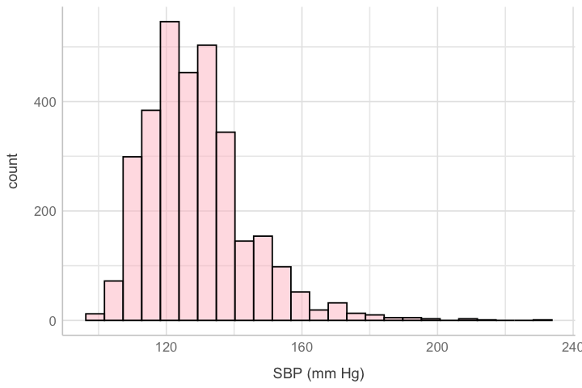

Figure 1: Histogram of systolic blood pressure (SBP) for the WCGS dataset.

```r
wcgs |>
  gf_histogram( ~ sbp, col = "black", fill = "pink")
```

**Important**

**Note**

1. At the start of the code, the first two lines (hidden on the final document) are:
- `#| label: fig-fig1`
- `#| fig-cap: "Histogram of systolic blood pressure (SBP) for the WCGS dataset."`
2. The label (name) of the chunk is: `fig-fig1`. When the label starts with `fig-`, the figure is automatically numbered. To refer to Figure 1 in the document we type: `@fig-fig1`.
3. The option `col` refers to the colour of the lines defining the bars; the option `fill` refers to the colour inside the bars.
4. You can look at the list of colours available by typing `colors()` in the *Console* panel.

In our first plot, the $y$-axis shows the frequency (counts), we may want to show the density (proportion) instead. Densities are preferred when comparing two or more distributions. To choose density we use `gf_dhistogram`:

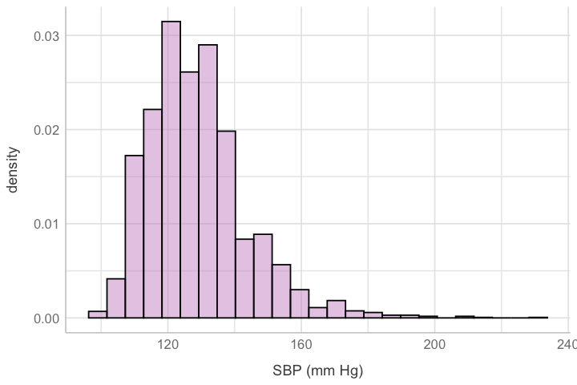

Figure 2: Histograms of systolic blood pressure (SBP) for the WCGS dataset.

```r
wcgs |>
  gf_dhistogram(~ sbp, col = "black", fill = "plum3")
```

We can compare groups using the `|` symbol, which can be understood as *given* or *by*:

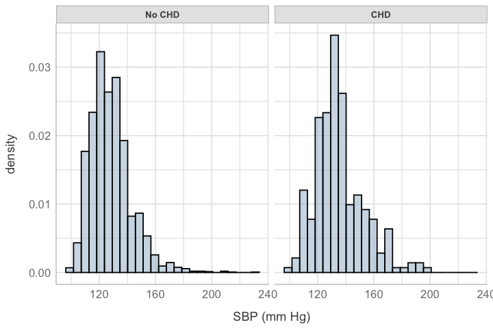

Figure 3: Histogram of systolic blood pressure (SBP) by coronary heart disease (CHD) event for the WCGS dataset.

```r
wcgs |>
  gf_dhistogram(~ sbp|chd, col = "black", fill = "slategray3")
```

To help on the interpretation of histograms, we can impose a density plot derived from a population with the same mean and standard deviation of the variable of interest. To make this plot, we can use the function `hist_norm` from the `pubh` package.

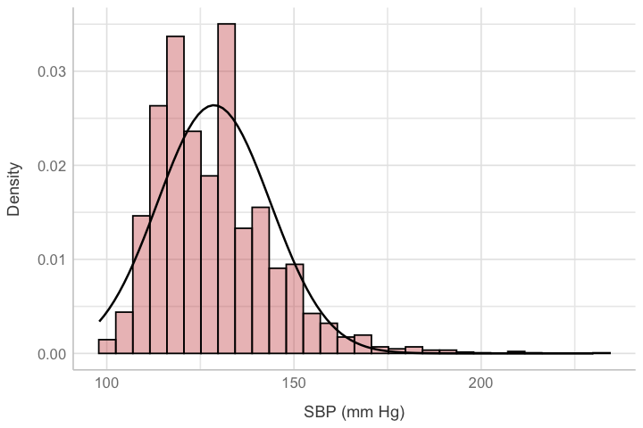

Figure 4: Histogram of systolic blood pressure (SBP) for the WCGS dataset. The black curve represents a density plot from a normal distribution.

```r
wcgs |>
  hist_norm(~ sbp, bins = 30)
```

## 3.2 Density plots

An alternative to histograms is density plots.

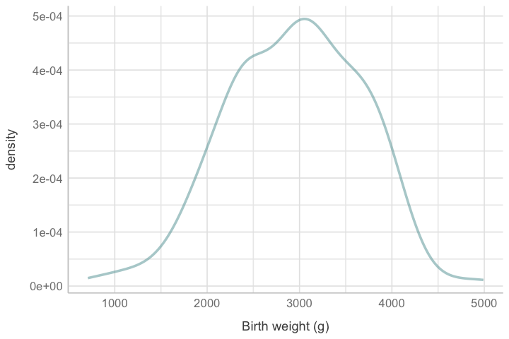

Figure 5: Distribution of birth weight.

```r
birthwt |>
  gf_dens(~ bwt, col = "cadetblue", lwd = 1)
```

We can use superimposed density plots to compare distributions.

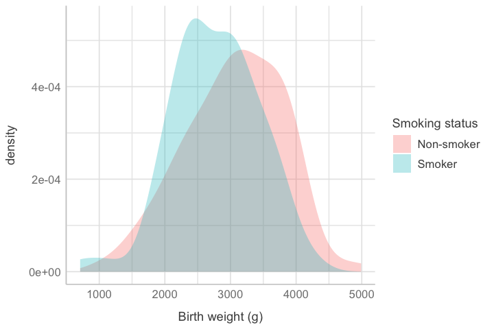

Figure 6: Comparison of birth weight distributions by mother’s smoking status.

```r
birthwt |>
  gf_density(~ bwt, fill = ~ smoke, alpha = 0.3)
```

**Note**

1. In the previous code, instead of displaying the distributions in two different panels (*faceting*) as we did with histograms, we are displaying them in the same panel but super-imposed.
2. By using the option `fill = ~ smoke`, we are telling `R` to select filling colours according to levels in the variable `smoke`.
3. With `alpha` we reduce the opacity, thus increase the transparency.
4. With `gf_dens` we plot only the contour whereas with `gf_density` the area under the curve is filled.

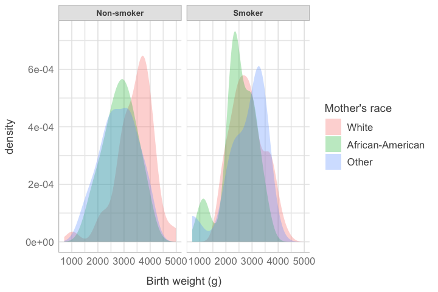

Figure 7: Comparison of birth weight distributions by smoking status of the mother and race of the mother.

```r
birthwt |>
  gf_density(~ bwt|smoke, fill = ~ race, alpha = 0.3)
```

**Important**

To help on the interpretation of histograms, we can impose a *density* plot derived from a population with the same mean and standard deviation of the variable of interest. To make this plot, we can use the function `hist_norm` from the `pubh` package.

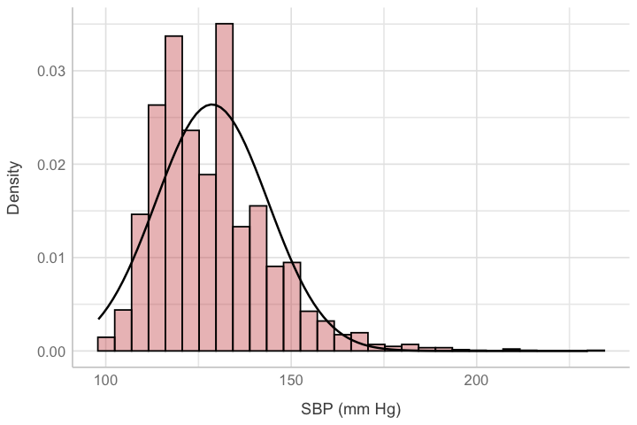

Figure 8: Histogram of systolic blood pressure (SBP) for the WCGS dataset. The black curve represents a density plot from a normal distribution.

```r
wcgs |>
  hist_norm(~ sbp, bins = 30)
```

## 3.3 QQ-plots

The best way to determine if a continuous variable is normally distributed or not is with quantile-quantile plots (QQ-plots). We plot the quantiles of our variable of interest against quantiles from the standard normal distribution (which has a mean $\mu=0$ and a standard deviation $\sigma=1$). This type of QQ-plots against the normal distribution are known as QQ-normal plots. If the variable is normally distributed, then a linear relationship will be observed.

To construct a QQ-plot we can use the function `qq_plot` from the `pubh` package. QQ-plots can be used even for relatively small samples.

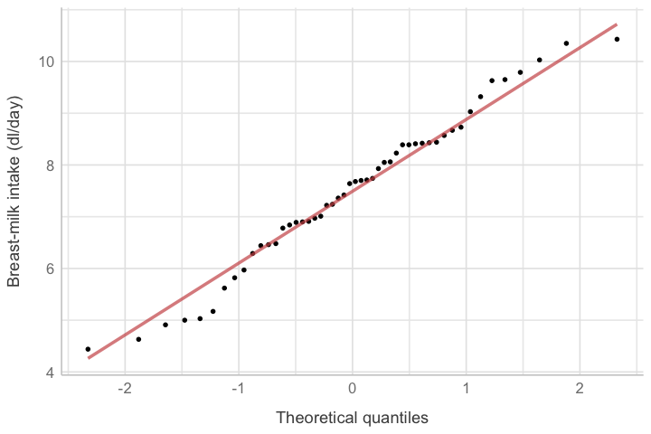

Figure 9: QQ-plot of breast-milk intake against the normal distribution.

```r
kfm |>
  qq_plot(~ dl.milk)
```

We can use `plots` to display more than one plot in a grid:

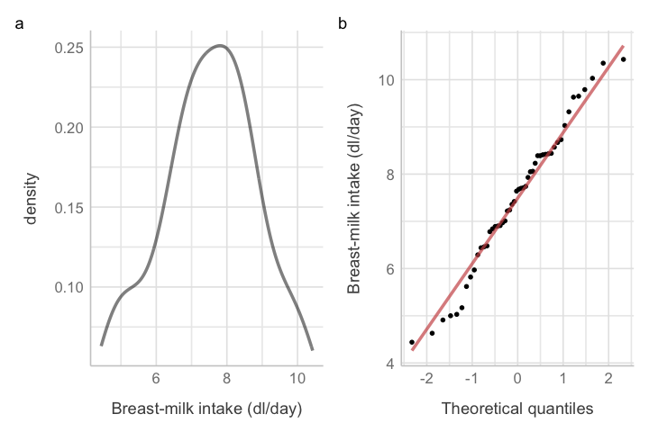

Figure 10: Distribution of breast-milk intake in infants. (a) Density plot. (b) QQ-plot against the normal distribution.

```r
p1 = kfm |>
  gf_dens(~ dl.milk, size = 1) |>
  axis_labs()

p2 = kfm |>
  qq_plot(~ dl.milk) |>
  axis_labs()

plots(p1, p2, n_columns = 2, tags = "a")
```

**Note**

1. The argument `n_columns = 2` is used to display the two plots on the same row. By default `n_columns = 1`.
2. With `tags = "a"` we are using lower case auto caption.
3. We need to include axis_labs when we display more than one plot as `ggormula` does not longer recognise the original label of the variable.

A variable that is positive-skewed is $J$-shaped in a QQ-plot.

**Exercise**

Using a QQ-plot, determine if SBP from normal subjects (no CHD event) in the `WCGS` dataset follows a normal distribution.

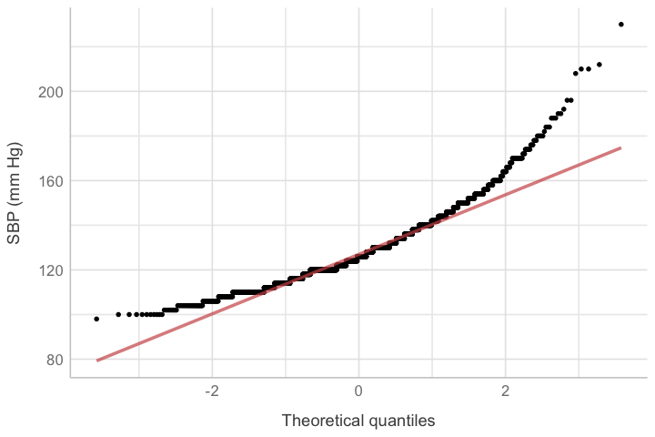

Figure 11: QQ-plot of systolic blood pressure (SBP) against the normal distribution, for subjects who did not present a coronary heart disease event in the WCGS dataset.

```r
wcgs |>
  filter(chd == "No CHD") |>
  copy_labels(wcgs) |>
  qq_plot(~ sbp)
```

**Answer**

The QQ-plots shows that the distribution of SBP in control subjects is positive skewed.

# 4 Associations between continuous variables

## 4.1 Scatter plots

We use scatter plots to look at the relationship between two continuous variables. By default, the dependent variable (response) is plotted on the $y$ axis while the independent variable (explanatory) is plotted on the $x$ axis.

From the `kfm` dataset, let’s see if there is a relationship between the weight of the mother and the breast-milk intake of the child.

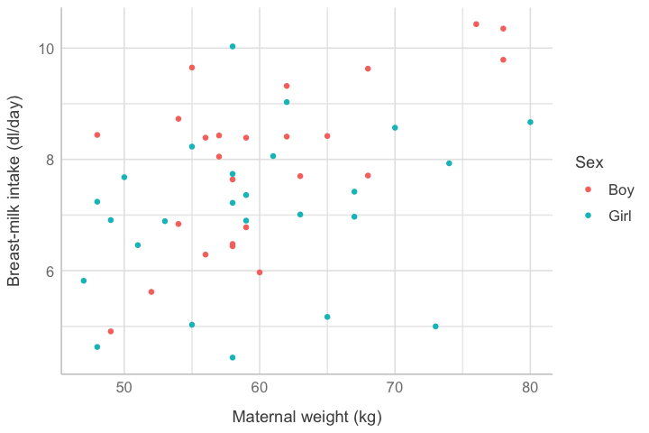

Figure 12: Relationship between maternal weight and breast-milk intake in infants.

```r
kfm |>
  gf_point(dl.milk ~ mat.weight, pch = 16,
           color = ~ sex, size = 1.5)
```

**Tip**

Figure 13 shows the most common symbols used in `R`. Symbols are defined with the option `pch`. For example, `pch = 17` would use filled triangles. You can also use symbols from the keyboard, for example `pch = "+"`, `pch = "o"`, `pch = "@"`, etc. When we have an enormous sample size, and we want to use a tiny symbol, we can type: `pch = "."`, alternatively, play with the option `size`.

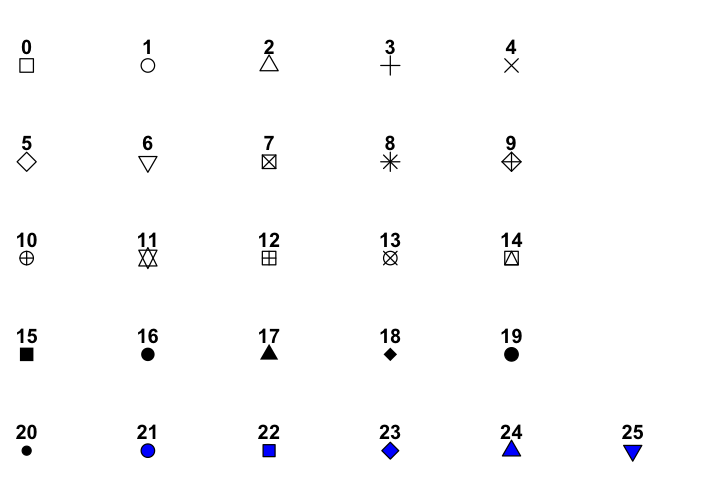

Figure 13: Common symbols used in `R`.

The advantage of `ggplot2` and `ggformula` is that plots can be extended and used for multivariate graphical analysis. For example, we could add a line representing a linear fit:

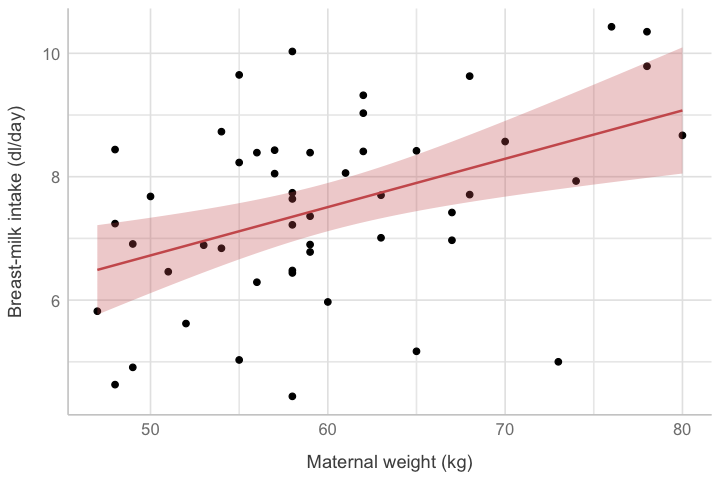

Figure 14: Relationship between maternal weight and breast-milk intake in infants.

```r
kfm |>
  gf_point(dl.milk ~ mat.weight) |>
  gf_lm(interval = "confidence", col = "indianred",
        fill = "indianred")
```

**Note**

1. We use `gf_lm` to fit a linear model (`lm`) and `gf_smooth` to show the trend (loess fit).
2. The default is to not show a band (`interval = "none"`). In the current example, we are showing the confidence intervals around the predicted fitted values.

We can plot, on the same panel, the relationship between maternal weight and breast-milk intake by sex.

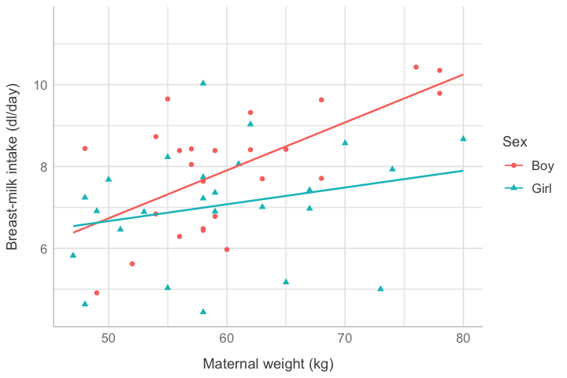

Figure 15: Relationship between maternal weight and breast-milk intake by sex.

```r
kfm |>
  gf_point(dl.milk ~ mat.weight,
           pch = ~ sex, col = ~ sex) |>
  gf_lm(col = ~ sex)
```

The package `ggsci` contains different palettes of colours for the most important journals (including *Nature*, *Science*, *NEJM*, etc.). Some examples:

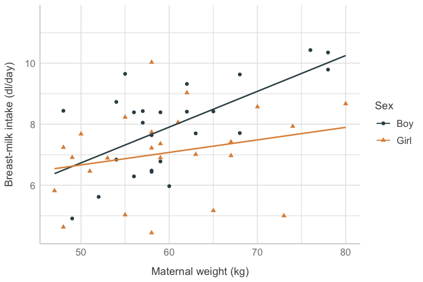

Figure 16: Relationship between maternal weight and breast-milk intake by sex. Plot uses palette of colours favoured by JAMA.

```r
kfm |>
  gf_point(dl.milk ~ mat.weight,
           pch = ~ sex, col = ~ sex) |>
  gf_lm(col = ~ sex) |>
  gf_refine(jama)
```

We already learnt how to construct *conditional* plots, i.e., to display plots in different panels *given* a particular condition (using the `|` symbol).

**Exercise**

Construct a plot showing the relationship between maternal weight and breast-milk intake by sex using one panel for each sex. Include a linear fit to your plot with corresponding bands of confidence intervals.

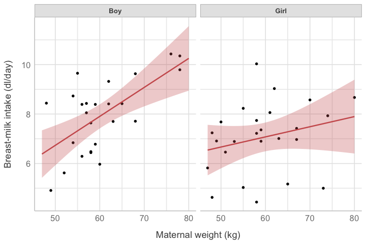

Figure 17: Relationship between maternal weight and breast-milk intake by sex.

```r
kfm |>
  gf_point(dl.milk ~ mat.weight|sex, pch = 20) |>
  gf_lm(interval = "confidence", col = "indianred",
        fill = "indianred")
```

## 4.2 Scatter plot matrix (supplementary, optional sub-section)

When we are working with more than two continuous variables and we want to look at potential correlations between them, we can generate a single plot, with all two-variable combinations displayed in different panels. This kind of plot is known as a scatter plot matrix and we can construct them with `ggpairs` from the package `GGally`.

**Tip**

`GGally` has two other functions that can also construct a scatter plot matrix: `ggduo` and `ggscatmat`; `ggapairs` is however, more flexible.

For example, we could be interested in looking at the relationship between pollution, expressed in ozone concentration, in relation with other environmental variables. We load the dataset:

```r
data(airquality)
airquality <- na.omit(airquality)
names(airquality)
```

1. 'Ozone'

2. 'Solar.R'

3. 'Wind'

4. 'Temp'

5. 'Month'

6. 'Day'

Next, we define the variable `Month` as a factor.

```r
mes = c("May", "Jun", "Jul", "Aug", "Sep")
airquality = airquality |>
  mutate(
    Month = factor(Month, labels = mes)
  )
```

Function `ggpairs` does not work well with labelled datasets so we are going to generate a vector with the labels of the variables:

```r
air = c(
  "Temperature (F)", "Wind (mph)",
  "Radiation (A)", "Ozone (ppb)"
)
```

In our first scatter plot matrix, we are going to show also the loess trend:

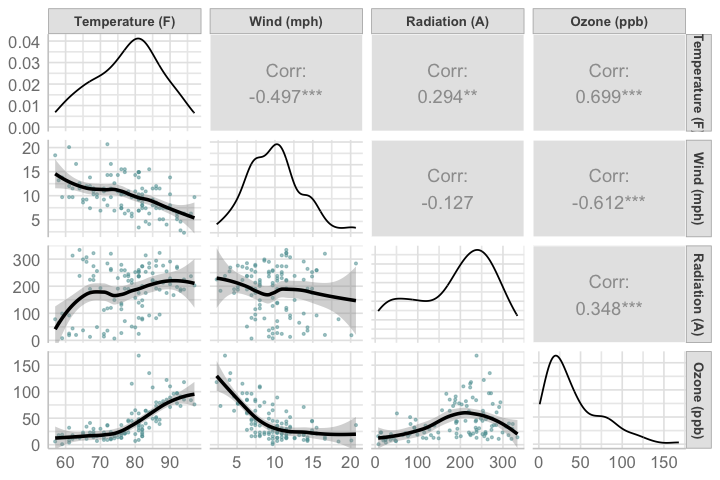

Figure 18: Relationship between pollution (ozone) and some environmental variables. Curves show loess trend.

```r
airquality |>
  ggpairs(
    columns = 4:1,
    lower = list(continuous = wrap("smooth_loess", alpha = 0.5,
                                   shape = 20, size = 0.9,
                                   color = "cadetblue")),
    columnLabels = air
  )
```

**Note**

1. With option `columns` we select which columns of the dataset we want to plot. The default (if omitted) is to plot all.
2. We selected columns from 4 to 1 because we want for `Ozone` to be displayed on the $y$-axis.
3. We use option `lower` to indicate what we want to plot on the *lower* diagonal.
4. We add a loess trend with `smooth_loess`. For a linear model, we would use `smooth`.
5. The diagonal shows the distributions of each variable. For continuous variables, the diagonal displays density plots and for categorical variables shows bar charts.
6. To understand the plot, focus on the bottom row. In panels of the bottom row, ozone is plotted on the $y$-axis; first against temperature, next against wind and finally, against solar radiation.

The `airquality` dataset includes a categorical variable, `Month` that we can use to stratify continuous variables.

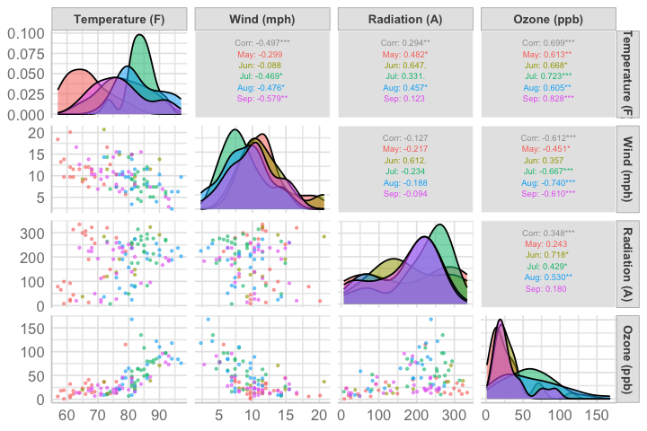

Figure 19: Relationship between pollution (ozone) and some environmental variables by month.

```r
airquality |>
  ggpairs(
    columns = 4:1,
    mapping = aes(color = Month, alpha = 0.8),
    lower = list(continuous = wrap("points",
                                   shape = 20, size = 1)),
    upper = list(continuous = wrap("cor", size = 2)),
    columnLabels = air
  )
```

**Important**

1. We use `mapping`, a function from `ggplot2` to stratify by `Month`. Please notice that `ggplot2` does not uses formulas, hence the lack of the tilde (`~`).
2. We used option `"points"` as to display only symbols with no added fit.
3. If we use `"smooth"` or `"smooth_loess"` we would have added a fit for each month making the plot harder to interpret.
4. We included the option `upper` only to decrease the size of the font to `size = 2`, so the information of the correlations fit well within the panels.

If our data is labelled, we need to remove the labels for `ggpair` to work. As usual, as long as we don’t assign the commands of the pipe-workflow to a variable (data frame) then our alterations will not be stored and will have only a local effect.

For example, let’s say we would like to look at relationships within the `kfm` dataset. In the following code, we remove the labels and we change the reference level of sex, just to display boys in blue and girls in pink.

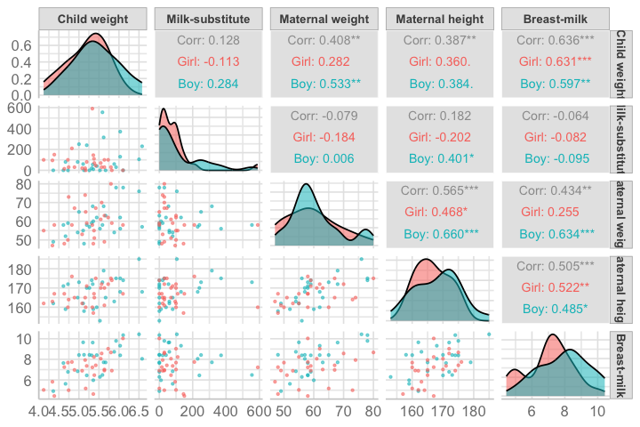

Figure 20: Relationship between breast-milk intake (dl/day) and other variables from the `kfm` dataset.

```r
kfm |>
  remove_all_labels() |>
  mutate(
    sex = relevel(sex, ref = "Girl")
  ) |>
  ggpairs(
    columns = c(4:7, 2),
    mapping = aes(color = sex, alpha = 0.8),
    lower = list(continuous = wrap("points",
                                   shape = 20, size = 1)),
    upper = list(continuous = wrap("cor", size = 3)),
    columnLabels = c(
      "Child weight",
      "Milk-substitute",
      "Maternal weight",
      "Maternal height",
      "Breast-milk"
    )
  )
```

## 4.3 Correlation plots

An alternative to scatter-plot matrices are correlation plots:

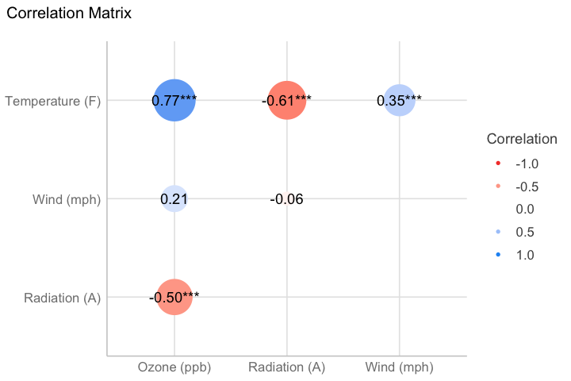

Figure 21: Correlation plot of continuous varialbes from the `airquality` dataset.

```r
airquality |>
  select(- c(Month, Day)) |>
  correlation(rename = air, method = "spearman") |>
  summary() |> plot(show_data = "points")
```

**Important**

1. Correlation plots have the disadvantage of not showing the actual relationship between the variables, nor to their distributions but only a visual representation of the correlation matrix.
2. Correlation is covered in the regression section.

## 4.4 Line charts

Sometimes, we don’t want to fit a trend or a linear model, but to actually connect all observations. With `gf_path` we connect observations in the order in which they appear in the data, whereas with `gf_line` we connect them in the order of the variable on the $x$-axis.

Perhaps, the best example when we want to connect observations is when we are working with time series data.

Download the file *fluraw.csv* from Moodle, save it on your *data* directory and load it to the session.

```r
flu = read_csv("data/fluraw.csv")
head(flu)
```

A tibble: 6 × 5

| week <date> | child <dbl> | young <dbl> | mid <dbl> | old <dbl> |
| --- | --- | --- | --- | --- |
| 1957-08-25 | 0 | 0 | 1 | 1 |
| 1957-09-01 | 0 | 2 | 6 | 1 |
| 1957-09-08 | 0 | 2 | 4 | 2 |
| 1957-09-15 | 23 | 73 | 63 | 11 |
| 1957-09-22 | 63 | 208 | 173 | 41 |
| 1957-09-29 | 73 | 207 | 171 | 27 |

```r
flu = flu |>
  var_labels(
    week = "Date"
  ) |>
  as.data.frame()
```

The data frame is recorded in what is known as *wide* format. We will use the function `pivot_longer` from `dplyr` to transform it to *long* format.

```r
flu_melt = flu |>
  pivot_longer(
    cols = !week,
    names_to = "agegrp",
    values_to = "cases"
  )

flu_melt |> head()
```

A tibble: 6 × 3

| week <date> | agegrp <chr> | cases <dbl> |
| --- | --- | --- |
| 1957-08-25 | child | 0 |
| 1957-08-25 | young | 0 |
| 1957-08-25 | mid | 1 |
| 1957-08-25 | old | 1 |
| 1957-09-01 | child | 0 |
| 1957-09-01 | young | 2 |

**Note**

1. We select the columns that we want to rearrange in `cols`. With `!week`, we are making a negative selection (read as *not week*).
2. The name of the new categorical variable is gen to `names_to`. The names of the columns are used as levels of the variable.
3. The actual values are stored in another variable, which name can be given at `values_to`.

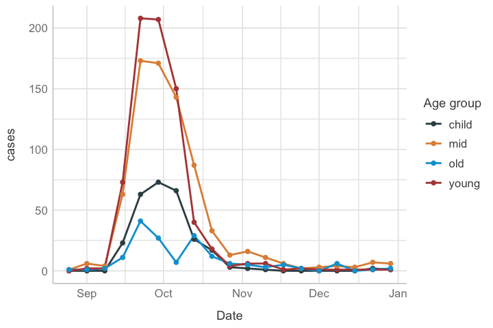

Figure 22: Dynamics of reported influenza cases by age group, in the 1957 pandemic in England and Wales.

```r
flu_melt |>
  gf_line(cases ~ week, col = ~ agegrp, size = 0.8) |>
  gf_point() |>
  gf_labs(col = "Age group") |>
  gf_refine(jama)
```

**Note**

## 4.5 Kaplan-Meier plots

Step plots are a variation of line charts in which the lines connect observations by steps instead of direct lines. The best example of step plots are those used in survival analysis as proposed by Kaplan and Meier.

For our example, we will use data about survival in patients with advanced lung cancer. We load the `survival` package to generate the information that we need to make a Kaplan-Meier plot. After loading the dataset, we transform variable `sex` to a factor.

**Caution**

For this tutorial, we are not interested in the modelling, only on constructing and interpreting the plot.

```r
library(survival)
data(cancer, package = "survival")
```

```r
lung = cancer |>
  mutate(
    Sex = factor(sex, labels = c("Male", "Female"))
  )
```

Next, we estimate survival stratified by sex:

```r
surv_fit = survfit(Surv(time, status) ~ Sex, data = lung)
surv_fit
```

```
Call: survfit(formula = Surv(time, status) ~ Sex, data = lung)

             n events median 0.95LCL 0.95UCL
Sex=Male   138    112    270     212     310
Sex=Female  90     53    426     348     550
```

We can use `autoplot` to construct the Kaplan-Meier plot:

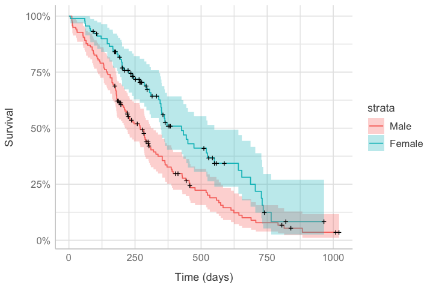

Figure 23: Kaplan-Meir plot for survival in patients with advanced lung cancer.

```r
autoplot(surv_fit) |>
  gf_labs(x = "Time (days)", y = "Survival")
```

# 5 Comparing groups

Many times, we are interested in comparing groups, for example:

- treatment vs control
- cases vs control
- drug A vs drug B
- females vs males

In these examples, the groups or cohorts represent the *explanatory* (exposure) variable. If the outcome is continuous, then we are interested in comparing distributions and/or a measure of central tendency.

## 5.1 Box plots

When we are comparing continuous variables, between two or more groups, box plots are the best option, particularly if the number of observations in the groups is relatively large ($\geq$ 30).

We are going to use the function `box_plot` from the `pubh` package to construct box plots.

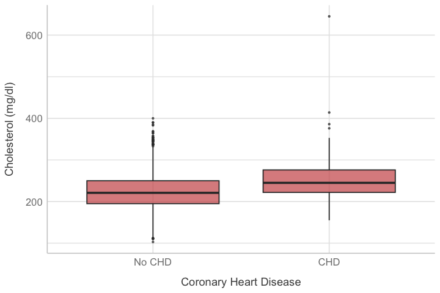

Figure 24: Box plots of blood cholesterol by coronary heart disease (CHD) event from the WCGS dataset.

```r
wcgs |>
  box_plot(chol ~ chd)
```

In the previous figure the presence of an outlier is clear. If we would like to remove that outlier, we would need to declare that in the report. For demonstration purposes, if we do not want to show the outlier in the plot, we have the option to `filter` the data as shown in the following code:

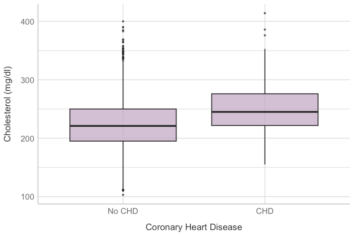

```r
wcgs |>
  filter(chol < 500) |>
  copy_labels(wcgs) |>
  box_plot(chol ~ chd, fill = "thistle3", alpha = 0.7)
```

## 5.2 Significant lines (supplementary, optional sub-section)

**Exercise**

Construct a plot comparing the distributions of breast-milk intake (`dl.milk`) by sex from the `kfm` data set.

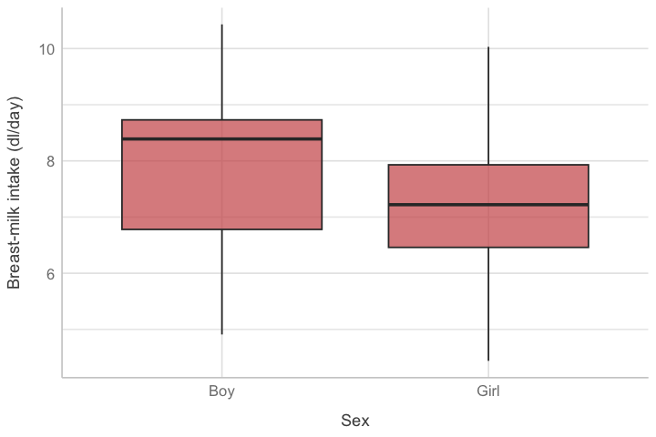

Figure 26: Comparison of breast-milk intake by sex.

```r
kfm |>
  box_plot(dl.milk ~ sex)
```

We can use box plots to show the results of our analysis. It happens that there is a significant difference in the mean value of breast-milk intake between boys and girls (we do not need to worry how to test this, yet). In our final report, if we would like to include a figure to show this difference, we can *draw* a line over the groups that we are comparing and *type* an asterisk to indicate the difference. To do that, we can use `gf_star` from the `pubh` package.

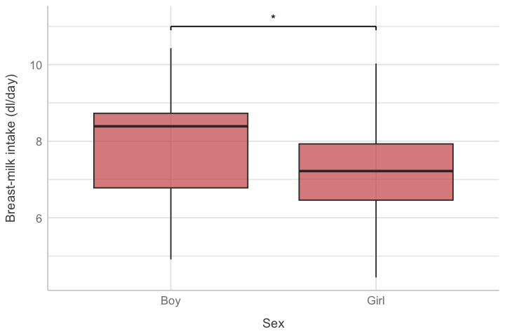

Figure 27: Comparison of breast-milk intake by sex ($^*p$ = 0.035, $t$-test).

```r
kfm |>
  box_plot(dl.milk ~ sex) |>
  gf_star(x1 = 1, y1 = 10.9, x2 = 2, y2 = 11, y3 = 11.2)
```

**Note**

1. By default, the centre of the boxes is drawn over integer numbers in the $x$-axis, starting with one.
2. We are providing points of reference to draw the line with `gf_star`.
3. `gf_star` draws a horizontal line from coordinate $(x_1, y_2)$ to coordinate $(x_2, y_2)$. Draws vertical lines below the horizontal line, towards data, from $(x_1, y_2)$ to $(x_1, y_1)$ and from $(x_2, y_2)$ to $(x_2, y_1)$. Finally, adds text above the horizontal line, at the mid point between $x_1$ and $x_2$, at height $y_3$.

It is possible to show the actual $p$-value in the plot. We can also, keep adding *layers* to the plot; for example, we can show all the observations, which we will *jitter* on the $x$-axis, so they can be better appreciated:

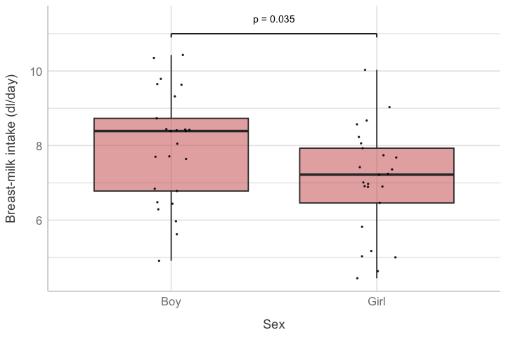

Figure 28: Comparison of breast-milk intake by sex.

```r
kfm |>
  box_plot(dl.milk ~ sex, alpha = 0.5) |>
  gf_jitter(dl.milk ~ sex, width = 0.1, height = 0,
            alpha = 0.8, pch = 20, size = 0.6) |>
  gf_star(1, 10.9, 2, 11, 11.4,
          legend = 'p = 0.035', size = 3)
```

## 5.3 Strip charts

When we want to compare groups and the number of observations is relatively small ($n$ < 30) box plots are not good. It is better to show all data in a variation of a scatter plot known as strip plot or strip chart.

We will use the data `energy` from the `ISwR` package about the energy expenditure of lean and obese women.

```r
data(energy, package = "ISwR")
head(energy)
```

A data.frame: 6 × 2

|  | expend <dbl> | stature <fct> |
| --- | --- | --- |
| 1 | 9.21 | obese |
| 2 | 7.53 | lean |
| 3 | 7.48 | lean |
| 4 | 8.08 | lean |
| 5 | 8.09 | lean |
| 6 | 10.15 | lean |

```r
energy = energy |>
  var_labels(
    expend = "Energy expenditure (MJ)",
    stature = "Stature"
  )

write_rds(energy, "data/energy.rds")
```

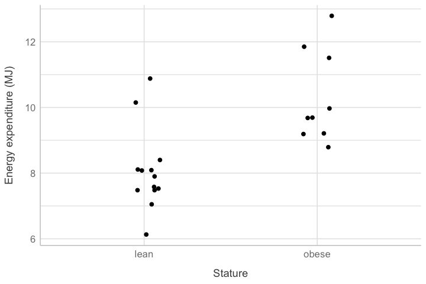

Figure 29: Comparison of energy between obese and lean women.

```r
energy |>
  gf_jitter(expend ~ stature, width = 0.1,
            height = 0)
```

It is easier to compare the groups if we include error bars showing the 95% confidence interval (CI) around the mean. To do that, we can use the function `strip_error` from the `pubh` package.

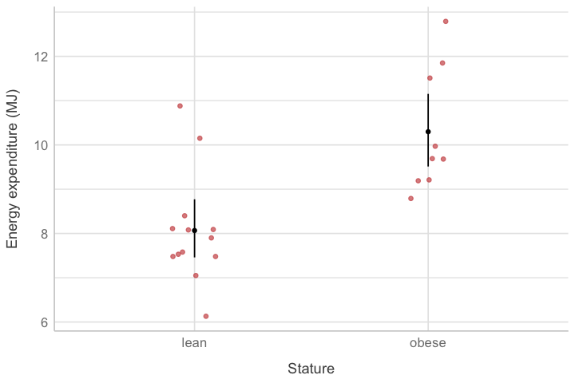

Figure 30: Comparison of energy expenditure between lean and obese women. Error bars represent bootstrap 95% CI.

```r
energy |>
  strip_error(expend ~ stature, size = 2)
```

**Note**

In `strip_error`, the argument `size` refers to the size of the symbols used to plot the individual observations.

The rationale to add a significant line is the same as for box plots.

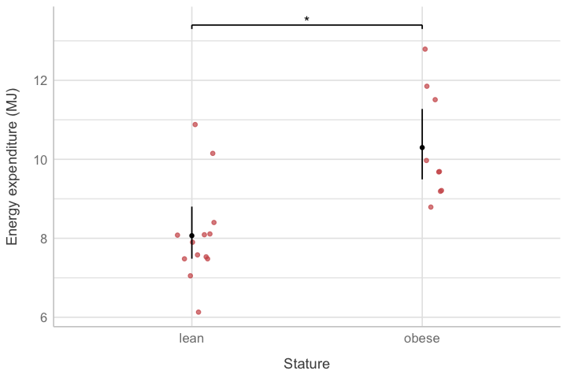

Figure 31: Comparison of energy expenditure between lean and obese women. Error bars represent 95% bootstrap CI ($^*p$ = 0.001, $t$-test).

```r
energy |>
  strip_error(expend ~ stature, size = 2) |>
  gf_star(1, 13.3, 2, 13.4, 13.5)
```

We can also construct strip plots with error bars, by groups.

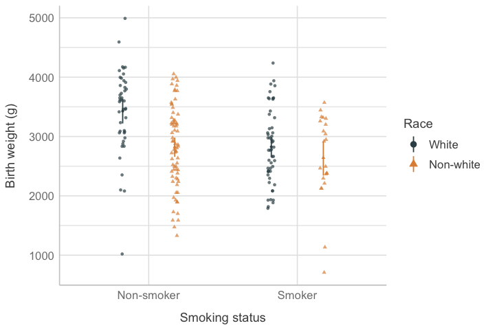

Figure 32: Comparison of birth weight of babies born from mothers with different smoking status by race. Error bars represent 95% bootstrap CI.

```r
birthwt |>
  strip_error(bwt ~ smoke, pch = ~ Race, col = ~ Race) |>
  gf_refine(jama)
```